# Bellabeat Case Study_Google Data Analytics Certificates

Shiang Ting (Noreen) Tseng

2023-10-03

# Bellabeat Case Study_Google Data Analytics Certificates

## Introduction to the Case Study

In the dynamic intersection of wellness and technology, Bellabeat emerges as a pioneering force, crafting a unique space where health-focused innovations meet the specific needs of women. This case study, “How Can a Wellness Technology Company Play It Smart?”, navigates through the intricate layers of Bellabeat’s operational and marketing strategies, unraveling the potential pathways to fortify its position in the global smart device market. Co-founded by Urška Sršen and Sando Mur, Bellabeat has not only manifested as a high-tech manufacturer of health-centric products but also as an entity that empowers women with data-driven insights into their health and habits. As we delve deeper, we will explore the company’s journey from its inception to its current standing, scrutinizing its products, marketing strategies, and the potential that smart device data analysis holds in unlocking new growth trajectories. This exploration aims to weave through the challenges and opportunities that lie ahead for Bellabeat, providing a comprehensive lens through which we can view and analyze its future prospects.

## My Responsibilities and Data Analysis Process

Navigating through the intricate pathways of data, my role as a junior data analyst unfolds, embarking on a meticulous journey through the realms of Bellabeat’s user data, with a particular focus on understanding the nuanced relationship between user activity and sleep patterns. My responsibilities are anchored in the systematic steps of the data analysis process: **ask, prepare, process, analyze, share, and act**. Initially, I will formulate critical questions, particularly probing into the correlations between users’ sleep patterns and varied activity levels. The subsequent steps involve preparing and processing the data, ensuring it is primed for a thorough analysis. My analysis will delve into examining the intricate relationships among users’ sleep patterns and different activity levels, scrutinizing correlations, and identifying potential causal relationships or anomalies.

The insights derived will not only be shared but will also be transformed into strategic recommendations, encompassing both marketing strategies and product improvement suggestions. I will develop insights, such as identifying correlations between activity and sleep, and translate them into strategic recommendations that span from feature development, like implementing smart alarms and enhancing the Bellabeat app, to user engagement and education, such as introducing activity-based challenges and developing educational content. Furthermore, I will recommend product enhancements and developments, ensuring they are intricately linked with the insights derived from the data, and propose marketing and communication strategies that leverage data-driven insights to enhance user engagement and brand positioning. This comprehensive approach ensures that the data not only informs but actively drives strategic decision-making and product development at Bellabeat, ensuring a symbiotic relationship between user data and organizational strategy.

# ASK

# Prepare

## Step 1. Download [FitBit Fitness Tracker Data | Kaggle](https://www.kaggle.com/datasets/arashnic/fitbit).

## Step 2. Choose relevant files

# PROCESS

```r
install.packages("tidyverse")
install.packages("dplyr")
install.packages("tidyr")
```

```r
install.packages("ggplot2")
install.packages("skimr")
install.packages("janitor")
```

## Step 3. Load necessary packages

```r
library(tidyverse)
```

```r
library(dplyr)
library(tidyr)
library(ggplot2)
library(skimr)
library(janitor)
```

```r
daily_activity <- read.csv("/cloud/project/Fitabase Data 4.12.16-5.12.16/dailyActivity_merged.csv")
sleep_pattern <- read.csv("/cloud/project/Fitabase Data 4.12.16-5.12.16/sleepDay_merged.csv")
# heart_rate <- read.csv("/cloud/project/Fitabase Data 4.12.16-5.12.16/heartrate_seconds_merged.csv")
# daily_mobility_activity <- read.csv("/cloud/project/Fitabase Data 4.12.16-5.12.16/dailySteps_merged.csv")
# hourly_mobility_activity <- read.csv("/cloud/project/Fitabase Data 4.12.16-5.12.16/hourlySteps_merged.csv")
```

## Step 5: Summarizing and Exploring data

### Previewing the data using head(), str(), colnames()

```r
noquote("Preview of Users' Daily Activity")
```

```
## [1] Preview of Users' Daily Activity
```

```r
head(daily_activity)
```

```
##           Id ActivityDate TotalSteps TotalDistance TrackerDistance
## 1 1503960366    4/12/2016      13162          8.50            8.50
## 2 1503960366    4/13/2016      10735          6.97            6.97
## 3 1503960366    4/14/2016      10460          6.74            6.74
## 4 1503960366    4/15/2016       9762          6.28            6.28
## 5 1503960366    4/16/2016      12669          8.16            8.16
## 6 1503960366    4/17/2016       9705          6.48            6.48
##   LoggedActivitiesDistance VeryActiveDistance ModeratelyActiveDistance
## 1                        0               1.88                     0.55
## 2                        0               1.57                     0.69
## 3                        0               2.44                     0.40
## 4                        0               2.14                     1.26
## 5                        0               2.71                     0.41
## 6                        0               3.19                     0.78
##   LightActiveDistance SedentaryActiveDistance VeryActiveMinutes
## 1                6.06                       0                25
## 2                4.71                       0                21
## 3                3.91                       0                30
## 4                2.83                       0                29
## 5                5.04                       0                36
## 6                2.51                       0                38
##   FairlyActiveMinutes LightlyActiveMinutes SedentaryMinutes Calories
## 1                  13                  328              728     1985
## 2                  19                  217              776     1797
## 3                  11                  181             1218     1776
## 4                  34                  209              726     1745
## 5                  10                  221              773     1863
## 6                  20                  164              539     1728
```

```r
str(daily_activity)
```

```
## 'data.frame':    940 obs. of  15 variables:
##  $ Id                      : num  1.5e+09 1.5e+09 1.5e+09 1.5e+09 1.5e+09 ...
##  $ ActivityDate            : chr  "4/12/2016" "4/13/2016" "4/14/2016" "4/15/2016" ...
##  $ TotalSteps              : int  13162 10735 10460 9762 12669 9705 13019 15506 10544 9819 ...
##  $ TotalDistance           : num  8.5 6.97 6.74 6.28 8.16 ...
##  $ TrackerDistance         : num  8.5 6.97 6.74 6.28 8.16 ...
##  $ LoggedActivitiesDistance: num  0 0 0 0 0 0 0 0 0 0 ...
##  $ VeryActiveDistance      : num  1.88 1.57 2.44 2.14 2.71 ...
##  $ ModeratelyActiveDistance: num  0.55 0.69 0.4 1.26 0.41 ...
##  $ LightActiveDistance     : num  6.06 4.71 3.91 2.83 5.04 ...
##  $ SedentaryActiveDistance : num  0 0 0 0 0 0 0 0 0 0 ...
##  $ VeryActiveMinutes       : int  25 21 30 29 36 38 42 50 28 19 ...
##  $ FairlyActiveMinutes     : int  13 19 11 34 10 20 16 31 12 8 ...
##  $ LightlyActiveMinutes    : int  328 217 181 209 221 164 233 264 205 211 ...
##  $ SedentaryMinutes        : int  728 776 1218 726 773 539 1149 775 818 838 ...
##  $ Calories                : int  1985 1797 1776 1745 1863 1728 1921 2035 1786 1775 ...
```

```r
glimpse(daily_activity)
```

```
## Rows: 940
## Columns: 15
## $ Id                       <dbl> 1503960366, 1503960366, 1503960366, 150396036…
## $ ActivityDate             <chr> "4/12/2016", "4/13/2016", "4/14/2016", "4/15/…
## $ TotalSteps               <int> 13162, 10735, 10460, 9762, 12669, 9705, 13019…
## $ TotalDistance            <dbl> 8.50, 6.97, 6.74, 6.28, 8.16, 6.48, 8.59, 9.8…
## $ TrackerDistance          <dbl> 8.50, 6.97, 6.74, 6.28, 8.16, 6.48, 8.59, 9.8…
## $ LoggedActivitiesDistance <dbl> 0, 0, 0, 0, 0, 0, 0, 0, 0, 0, 0, 0, 0, 0, 0, …
## $ VeryActiveDistance       <dbl> 1.88, 1.57, 2.44, 2.14, 2.71, 3.19, 3.25, 3.5…
## $ ModeratelyActiveDistance <dbl> 0.55, 0.69, 0.40, 1.26, 0.41, 0.78, 0.64, 1.3…
## $ LightActiveDistance      <dbl> 6.06, 4.71, 3.91, 2.83, 5.04, 2.51, 4.71, 5.0…
## $ SedentaryActiveDistance  <dbl> 0, 0, 0, 0, 0, 0, 0, 0, 0, 0, 0, 0, 0, 0, 0, …
## $ VeryActiveMinutes        <int> 25, 21, 30, 29, 36, 38, 42, 50, 28, 19, 66, 4…
## $ FairlyActiveMinutes      <int> 13, 19, 11, 34, 10, 20, 16, 31, 12, 8, 27, 21…
## $ LightlyActiveMinutes     <int> 328, 217, 181, 209, 221, 164, 233, 264, 205, …
## $ SedentaryMinutes         <int> 728, 776, 1218, 726, 773, 539, 1149, 775, 818…
## $ Calories                 <int> 1985, 1797, 1776, 1745, 1863, 1728, 1921, 203…
```

```r
noquote("Preview of Column Names of Users' Daily Activity")
```

```
## [1] Preview of Column Names of Users' Daily Activity
```

```r
colnames(daily_activity)
```

```
##  [1] "Id"                       "ActivityDate"
##  [3] "TotalSteps"               "TotalDistance"
##  [5] "TrackerDistance"          "LoggedActivitiesDistance"
##  [7] "VeryActiveDistance"       "ModeratelyActiveDistance"
##  [9] "LightActiveDistance"      "SedentaryActiveDistance"
## [11] "VeryActiveMinutes"        "FairlyActiveMinutes"
## [13] "LightlyActiveMinutes"     "SedentaryMinutes"
## [15] "Calories"
```

```r
noquote("Preview of Users' Sleep Pattern")
```

```
## [1] Preview of Users' Sleep Pattern
```

```r
head(sleep_pattern)
```

```
##           Id              SleepDay TotalSleepRecords TotalMinutesAsleep
## 1 1503960366 4/12/2016 12:00:00 AM                 1                327
## 2 1503960366 4/13/2016 12:00:00 AM                 2                384
## 3 1503960366 4/15/2016 12:00:00 AM                 1                412
## 4 1503960366 4/16/2016 12:00:00 AM                 2                340
## 5 1503960366 4/17/2016 12:00:00 AM                 1                700
## 6 1503960366 4/19/2016 12:00:00 AM                 1                304
##   TotalTimeInBed
## 1            346
## 2            407
## 3            442
## 4            367
## 5            712
## 6            320
```

```r
str(sleep_pattern)
```

```
## 'data.frame':    413 obs. of  5 variables:
##  $ Id                : num  1.5e+09 1.5e+09 1.5e+09 1.5e+09 1.5e+09 ...
##  $ SleepDay          : chr  "4/12/2016 12:00:00 AM" "4/13/2016 12:00:00 AM" "4/15/2016 12:00:00 AM" "4/16/2016 12:00:00 AM" ...
##  $ TotalSleepRecords : int  1 2 1 2 1 1 1 1 1 1 ...
##  $ TotalMinutesAsleep: int  327 384 412 340 700 304 360 325 361 430 ...
##  $ TotalTimeInBed    : int  346 407 442 367 712 320 377 364 384 449 ...
```

```r
glimpse(sleep_pattern)
```

```
## Rows: 413
## Columns: 5
## $ Id                 <dbl> 1503960366, 1503960366, 1503960366, 1503960366, 150…
## $ SleepDay           <chr> "4/12/2016 12:00:00 AM", "4/13/2016 12:00:00 AM", "…
## $ TotalSleepRecords  <int> 1, 2, 1, 2, 1, 1, 1, 1, 1, 1, 1, 1, 1, 1, 1, 1, 1, …
## $ TotalMinutesAsleep <int> 327, 384, 412, 340, 700, 304, 360, 325, 361, 430, 2…
## $ TotalTimeInBed     <int> 346, 407, 442, 367, 712, 320, 377, 364, 384, 449, 3…
```

```r
noquote("Preview of Column Names of Users' Sleep Pattern")
```

```
## [1] Preview of Column Names of Users' Sleep Pattern
```

```r
colnames(sleep_pattern)
```

```
## [1] "Id"                 "SleepDay"           "TotalSleepRecords"
## [4] "TotalMinutesAsleep" "TotalTimeInBed"
```

## Step 6. Data Cleaning Process

- Check whether the data is duplicated.
- Remove NA values.

### Duplicated data

```r
noquote("The number of duplicated rows")
```

```
## [1] The number of duplicated rows
```

```r
daily_activity %>% duplicated() %>% sum() %>% cat(" duplicated rows in daily_activity. \n")
```

```
## 0  duplicated rows in daily_activity.
```

```r
sleep_pattern %>% duplicated() %>% sum() %>% cat(" duplicated rows in sleep_pattern. \n")
```

```
## 3  duplicated rows in sleep_pattern.
```

```r
# daily_mobility_activity %>% duplicated() %>% sum() %>% cat(" duplicated rows in daily_mobility_activity \n")
# hourly_mobility_activity %>% duplicated() %>% sum() %>% cat(" duplicated rows in hourly_mobility_activity \n")
# heart_rate %>% duplicated() %>% sum() %>% cat(" duplicated rows in heart_rate. \n")
```

- Print duplicated rows.

```r
# Identify duplicated rows
duplicated_daily_activity_rows <- duplicated(daily_activity)

# Check and display duplicated rows
if(sum(duplicated_daily_activity_rows) > 0){
  cat("Duplicated rows: \n")
  print(daily_activity[duplicated_daily_activity_rows, ])
} else {
  cat("No duplicated rows in daily_activity. \n")
}
```

```
## No duplicated rows in daily_activity.
```

```r
# Identify duplicated rows by column Id and SleepDay at the same time
duplicated_sleep_pattern_rows <- duplicated(sleep_pattern, subset = c("Id", "SleepDay")) & duplicated(sleep_pattern, subset = c("Id", "SleepDay"), fromLast = TRUE)

# Check and display duplicated rows
if(sum(duplicated_sleep_pattern_rows) > 0){
  cat("Duplicated rows: \n")
  print(sleep_pattern[duplicated_sleep_pattern_rows, ])
} else {
  cat("No duplicated rows in sleep_pattern. \n")
}
```

```
## No duplicated rows in sleep_pattern.
```

### Null values

```r
noquote("The number of NULL values in rows")
```

```
## [1] The number of NULL values in rows
```

```r
daily_activity %>% is.na() %>% sum() %>% cat(" NULL values in daily_activity. \n")
```

```
## 0  NULL values in daily_activity.
```

```r
sleep_pattern %>% is.na() %>% sum() %>% cat(" NULL values in sleep_pattern. \n")
```

```
## 0  NULL values in sleep_pattern.
```

```r
# heart_rate %>% is.na() %>% sum() %>% cat(" NULL values in heart_rate. \n")
# daily_mobility_activity %>% is.na() %>% sum() %>% cat(" NULL values in daily_mobility_activity \n")
# hourly_mobility_activity %>% is.na() %>% sum() %>% cat(" NULL values in hourly_mobility_activity \n")
```

- Print NULL values in rows.

```r
na_check <- is.na(daily_activity)
if(sum(na_check) > 0){
  cat("NULL value in rows: \n")
  print(daily_activity[na_check, ])
} else{
  cat("No NULL values in daily_activity. \n")
}
```

```
## No NULL values in daily_activity.
```

```r
na_check <- is.na(sleep_pattern)
if(sum(na_check) > 0){
  cat("NULL value in rows: \n")
  print(sleep_pattern[na_check, ])
} else{
  cat("No NULL values in daily_activity. \n")
}
```

```
## No NULL values in daily_activity.
```

## Step 7. Transforming Data

To uniform the formation of date, the column SleepDay was separated first in sleep_pattern.

```r
sleep_pattern <- sleep_pattern %>% separate(SleepDay, into = c("Date", "Time"), sep = " ", extra = "merge")
```

To better understand the amount of time subjects spent on daily activity, the total activity time was calculated.

```r
daily_activity <- daily_activity %>% mutate(TotalActivityTime = VeryActiveMinutes + FairlyActiveMinutes + LightlyActiveMinutes + SedentaryMinutes)
```

To better understand the amount of time subjects spent on falling asleep, the sleep latency was calculated.

```r
sleep_pattern <- sleep_pattern %>% mutate(SleepLatency = TotalTimeInBed - TotalMinutesAsleep)
```

## Step 8. Data Frames Preparation

To review the relationship between total activities(total Steps, Distance, Time) and sleep time, the following data was extracting from daily_activity and sleep_pattern:

```r
noquote("Extraction of Total Steps, Total Distance, and Total Activity Time from daily activities")
```

```
## [1] Extraction of Total Steps, Total Distance, and Total Activity Time from daily activities
```

```r
total_activities <- daily_activity %>% group_by(Id) %>% summarise(TotalSteps = sum(TotalSteps), TotalDistance = sum(TotalDistance), TotalActivityTime = sum(TotalActivityTime))

noquote("Extraction of Total Active Steps, Total Active Distance, and Total Active Activity Time from daily activities")
```

```
## [1] Extraction of Total Active Steps, Total Active Distance, and Total Active Activity Time from daily activities
```

```r
very_active_activity <- daily_activity %>% group_by(Id) %>% summarise(VeryActiveTotalDistance = sum(VeryActiveDistance), VeryActiveTotalTime = sum(VeryActiveMinutes))

noquote("Extraction of Total Moderate Steps, Total Moderate Distance, and Total Moderate Activity Time from daily activities")
```

```
## [1] Extraction of Total Moderate Steps, Total Moderate Distance, and Total Moderate Activity Time from daily activities
```

```r
mid_active_activity <- daily_activity %>% group_by(Id) %>% summarise(MidActiveTotalDistance = sum(ModeratelyActiveDistance), MidActiveTotalTime = sum(FairlyActiveMinutes))

noquote("Extraction of Total Light Steps, Total Light Distance, and Total Light Activity Time from daily activities")
```

```
## [1] Extraction of Total Light Steps, Total Light Distance, and Total Light Activity Time from daily activities
```

```r
light_active_activity <- daily_activity %>% group_by(Id) %>% summarise(LightActiveTotalDistance = sum(LightActiveDistance), LightActiveTotalTime = sum(LightlyActiveMinutes))

noquote("Extraction of Total Sed Steps, Total Sedentary Distance, and Total Sed Activity Time from daily activities")
```

```
## [1] Extraction of Total Sed Steps, Total Sedentary Distance, and Total Sed Activity Time from daily activities
```

```r
sed_active_activity <- daily_activity %>% group_by(Id) %>% summarise(SedActiveTotalDistance = sum(SedentaryActiveDistance), SedActiveTotalTime = sum(SedentaryMinutes))

noquote("Extraction of Total Asleep Time, Total Time in Bed, and Total Sleep Latency Time from sleep pattern")
```

```
## [1] Extraction of Total Asleep Time, Total Time in Bed, and Total Sleep Latency Time from sleep pattern
```

```r
sleep <- sleep_pattern %>% group_by(Id) %>% summarise(AsleepTime = sum(TotalMinutesAsleep), BedTime = sum(TotalTimeInBed), SleepLatency = sum(SleepLatency))
```

## Step 9. Merging Data

```r
noquote("Total Activity <----> Sleep")
```

```
## [1] Total Activity <----> Sleep
```

```r
total_activities_and_sleep <- total_activities %>% inner_join(sleep, by = c("Id"))

noquote("Total Active Activity <----> Sleep")
```

```
## [1] Total Active Activity <----> Sleep
```

```r
very_active_activities_and_sleep <- very_active_activity %>% inner_join(sleep, by = c("Id"))

noquote("Total Moderate Activity <----> Sleep")
```

```
## [1] Total Moderate Activity <----> Sleep
```

```r
mid_active_activity_and_sleep <- mid_active_activity %>% inner_join(sleep, by = c("Id"))

noquote("Total Light Activity <----> Sleep")
```

```
## [1] Total Light Activity <----> Sleep
```

```r
light_active_activity_and_sleep <- light_active_activity %>% inner_join(sleep, by = c("Id"))

noquote("Total Sedentary Activity <----> Sleep")
```

```
## [1] Total Sedentary Activity <----> Sleep
```

```r
sed_active_activity_and_sleep <- sed_active_activity %>% inner_join(sleep, by = c("Id"))
```

## Step 10. Preview of All the Data Frames

In the final step of processing data, all the data frames need to be checked for the preparation for ANALYSIS.

```r
noquote("Preview of Users' Total Activity and Sleep")
```

```
## [1] Preview of Users' Total Activity and Sleep
```

```r
noquote("Total Activity <----> Sleep")
```

```
## [1] Total Activity <----> Sleep
```

```r
head(total_activities_and_sleep)
```

```
## # A tibble: 6 × 7
##           Id TotalSteps TotalDistance TotalActivityTime AsleepTime BedTime
##        <dbl>      <int>         <dbl>             <int>      <int>   <int>
## 1 1503960366     375619         242.              34905       9007    9580
## 2 1644430081     218489         159.              41138       1176    1384
## 3 1844505072      79982          52.9             41028       1956    2883
## 4 1927972279      28400          19.7             42101       2085    2189
## 5 2026352035     172573         107.              29339      14173   15054
## 6 2320127002     146223          98.8             44089         61      69
## # ℹ 1 more variable: SleepLatency <int>
```

```r
str(total_activities_and_sleep)
```

```
## tibble [24 × 7] (S3: tbl_df/tbl/data.frame)
##  $ Id               : num [1:24] 1.50e+09 1.64e+09 1.84e+09 1.93e+09 2.03e+09 ...
##  $ TotalSteps       : int [1:24] 375619 218489 79982 28400 172573 146223 171354 329537 70284 225334 ...
##  $ TotalDistance    : num [1:24] 242.1 158.9 52.9 19.7 107.1 ...
##  $ TotalActivityTime: int [1:24] 34905 41138 41028 42101 29339 44089 17527 28874 41067 30395 ...
##  $ AsleepTime       : int [1:24] 9007 1176 1956 2085 14173 61 6702 8222 2795 12393 ...
##  $ BedTime          : int [1:24] 9580 1384 2883 2189 15054 69 7370 12912 3038 13051 ...
##  $ SleepLatency     : int [1:24] 573 208 927 104 881 8 668 4690 243 658 ...
```

```r
glimpse(total_activities_and_sleep)
```

```
## Rows: 24
## Columns: 7
## $ Id                <dbl> 1503960366, 1644430081, 1844505072, 1927972279, 2026…
## $ TotalSteps        <int> 375619, 218489, 79982, 28400, 172573, 146223, 171354…
## $ TotalDistance     <dbl> 242.10, 158.86, 52.89, 19.67, 107.10, 98.82, 114.40,…
## $ TotalActivityTime <int> 34905, 41138, 41028, 42101, 29339, 44089, 17527, 288…
## $ AsleepTime        <int> 9007, 1176, 1956, 2085, 14173, 61, 6702, 8222, 2795,…
## $ BedTime           <int> 9580, 1384, 2883, 2189, 15054, 69, 7370, 12912, 3038…
## $ SleepLatency      <int> 573, 208, 927, 104, 881, 8, 668, 4690, 243, 658, 554…
```

```r
noquote("Preview of Column Names of Users' Total Activity and Sleep")
```

```
## [1] Preview of Column Names of Users' Total Activity and Sleep
```

```r
colnames(total_activities_and_sleep)
```

```
## [1] "Id"                "TotalSteps"        "TotalDistance"
## [4] "TotalActivityTime" "AsleepTime"        "BedTime"
## [7] "SleepLatency"
```

```r
noquote("Preview of Users' Very Active Activity and Sleep")
```

```
## [1] Preview of Users' Very Active Activity and Sleep
```

```r
noquote("Total Active Activity <----> Sleep")
```

```
## [1] Total Active Activity <----> Sleep
```

```r
head(very_active_activities_and_sleep)
```

```
## # A tibble: 6 × 6
##           Id VeryActiveTotalDistance VeryActiveTotalTime AsleepTime BedTime
##        <dbl>                   <dbl>               <int>      <int>   <int>
## 1 1503960366                  88.6                  1200       9007    9580
## 2 1644430081                  21.9                   287       1176    1384
## 3 1844505072                   0.260                   4       1956    2883
## 4 1927972279                   2.97                   41       2085    2189
## 5 2026352035                   0.190                   3      14173   15054
## 6 2320127002                   3.31                   42         61      69
## # ℹ 1 more variable: SleepLatency <int>
```

```r
str(very_active_activities_and_sleep)
```

```
## tibble [24 × 6] (S3: tbl_df/tbl/data.frame)
##  $ Id                     : num [1:24] 1.50e+09 1.64e+09 1.84e+09 1.93e+09 2.03e+09 ...
##  $ VeryActiveTotalDistance: num [1:24] 88.61 21.9 0.26 2.97 0.19 ...
##  $ VeryActiveTotalTime    : int [1:24] 1200 287 4 41 3 42 243 567 161 111 ...
##  $ AsleepTime             : int [1:24] 9007 1176 1956 2085 14173 61 6702 8222 2795 12393 ...
##  $ BedTime                : int [1:24] 9580 1384 2883 2189 15054 69 7370 12912 3038 13051 ...
##  $ SleepLatency           : int [1:24] 573 208 927 104 881 8 668 4690 243 658 ...
```

```r
glimpse(very_active_activities_and_sleep)
```

```
## Rows: 24
## Columns: 6
## $ Id                      <dbl> 1503960366, 1644430081, 1844505072, 1927972279…
## $ VeryActiveTotalDistance <dbl> 88.61, 21.90, 0.26, 2.97, 0.19, 3.31, 19.07, 4…
## $ VeryActiveTotalTime     <int> 1200, 287, 4, 41, 3, 42, 243, 567, 161, 111, 7…
## $ AsleepTime              <int> 9007, 1176, 1956, 2085, 14173, 61, 6702, 8222,…
## $ BedTime                 <int> 9580, 1384, 2883, 2189, 15054, 69, 7370, 12912…
## $ SleepLatency            <int> 573, 208, 927, 104, 881, 8, 668, 4690, 243, 65…
```

```r
noquote("Preview of Column Names of Users' Very Active Activity and Sleep")
```

```
## [1] Preview of Column Names of Users' Very Active Activity and Sleep
```

```r
colnames(very_active_activities_and_sleep)
```

```
## [1] "Id"                      "VeryActiveTotalDistance"
## [3] "VeryActiveTotalTime"     "AsleepTime"
## [5] "BedTime"                 "SleepLatency"
```

```r
noquote("Preview of Users' Moderate Active Activity and Sleep")
```

```
## [1] Preview of Users' Moderate Active Activity and Sleep
```

```r
noquote("Total Moderate Activity <----> Sleep")
```

```
## [1] Total Moderate Activity <----> Sleep
```

```r
head(mid_active_activity_and_sleep)
```

```
## # A tibble: 6 × 6
##           Id MidActiveTotalDistance MidActiveTotalTime AsleepTime BedTime
##        <dbl>                  <dbl>              <int>      <int>   <int>
## 1 1503960366                 24.6                  594       9007    9580
## 2 1644430081                 28.5                  641       1176    1384
## 3 1844505072                  1.52                  40       1956    2883
## 4 1927972279                  0.970                 24       2085    2189
## 5 2026352035                  0.350                  8      14173   15054
## 6 2320127002                  3.03                  80         61      69
## # ℹ 1 more variable: SleepLatency <int>
```

```r
str(mid_active_activity_and_sleep)
```

```
## tibble [24 × 6] (S3: tbl_df/tbl/data.frame)
##  $ Id                    : num [1:24] 1.50e+09 1.64e+09 1.84e+09 1.93e+09 2.03e+09 ...
##  $ MidActiveTotalDistance: num [1:24] 24.62 28.53 1.52 0.97 0.35 ...
##  $ MidActiveTotalTime    : int [1:24] 594 641 40 24 8 80 370 1838 166 382 ...
##  $ AsleepTime            : int [1:24] 9007 1176 1956 2085 14173 61 6702 8222 2795 12393 ...
##  $ BedTime               : int [1:24] 9580 1384 2883 2189 15054 69 7370 12912 3038 13051 ...
##  $ SleepLatency          : int [1:24] 573 208 927 104 881 8 668 4690 243 658 ...
```

```r
glimpse(mid_active_activity_and_sleep)
```

```
## Rows: 24
## Columns: 6
## $ Id                     <dbl> 1503960366, 1644430081, 1844505072, 1927972279,…
## $ MidActiveTotalDistance <dbl> 24.62, 28.53, 1.52, 0.97, 0.35, 3.03, 19.35, 82…
## $ MidActiveTotalTime     <int> 594, 641, 40, 24, 8, 80, 370, 1838, 166, 382, 6…
## $ AsleepTime             <int> 9007, 1176, 1956, 2085, 14173, 61, 6702, 8222, …
## $ BedTime                <int> 9580, 1384, 2883, 2189, 15054, 69, 7370, 12912,…
## $ SleepLatency           <int> 573, 208, 927, 104, 881, 8, 668, 4690, 243, 658…
```

```r
noquote("Preview of Column Names of Users' Moderate Active Activity and Sleep")
```

```
## [1] Preview of Column Names of Users' Moderate Active Activity and Sleep
```

```r
colnames(mid_active_activity_and_sleep)
```

```
## [1] "Id"                     "MidActiveTotalDistance" "MidActiveTotalTime"
## [4] "AsleepTime"             "BedTime"                "SleepLatency"
```

```r
noquote("Preview of Users' Light Active Activity and Sleep")
```

```
## [1] Preview of Users' Light Active Activity and Sleep
```

```r
noquote("Total Light Activity <----> Sleep")
```

```
## [1] Total Light Activity <----> Sleep
```

```r
head(light_active_activity_and_sleep)
```

```
## # A tibble: 6 × 6
##           Id LightActiveTotalDistance LightActiveTotalTime AsleepTime BedTime
##        <dbl>                    <dbl>                <int>      <int>   <int>
## 1 1503960366                    129.                  6818       9007    9580
## 2 1644430081                    108.                  5354       1176    1384
## 3 1844505072                     51.1                 3579       1956    2883
## 4 1927972279                     15.7                 1196       2085    2189
## 5 2026352035                    107.                  7956      14173   15054
## 6 2320127002                     92.4                 6144         61      69
## # ℹ 1 more variable: SleepLatency <int>
```

```r
str(light_active_activity_and_sleep)
```

```
## tibble [24 × 6] (S3: tbl_df/tbl/data.frame)
##  $ Id                      : num [1:24] 1.50e+09 1.64e+09 1.84e+09 1.93e+09 2.03e+09 ...
##  $ LightActiveTotalDistance: num [1:24] 128.7 108.3 51.1 15.7 106.5 ...
##  $ LightActiveTotalTime    : int [1:24] 6818 5354 3579 1196 7956 6144 4545 5243 2385 7092 ...
##  $ AsleepTime              : int [1:24] 9007 1176 1956 2085 14173 61 6702 8222 2795 12393 ...
##  $ BedTime                 : int [1:24] 9580 1384 2883 2189 15054 69 7370 12912 3038 13051 ...
##  $ SleepLatency            : int [1:24] 573 208 927 104 881 8 668 4690 243 658 ...
```

```r
glimpse(light_active_activity_and_sleep)
```

```
## Rows: 24
## Columns: 6
## $ Id                       <dbl> 1503960366, 1644430081, 1844505072, 192797227…
## $ LightActiveTotalDistance <dbl> 128.74, 108.27, 51.07, 15.72, 106.52, 92.39, …
## $ LightActiveTotalTime     <int> 6818, 5354, 3579, 1196, 7956, 6144, 4545, 524…
## $ AsleepTime               <int> 9007, 1176, 1956, 2085, 14173, 61, 6702, 8222…
## $ BedTime                  <int> 9580, 1384, 2883, 2189, 15054, 69, 7370, 1291…
## $ SleepLatency             <int> 573, 208, 927, 104, 881, 8, 668, 4690, 243, 6…
```

```r
noquote("Preview of Column Names of Users' Light Active Activity and Sleep")
```

```
## [1] Preview of Column Names of Users' Light Active Activity and Sleep
```

```r
colnames(light_active_activity_and_sleep)
```

```
## [1] "Id"                       "LightActiveTotalDistance"
## [3] "LightActiveTotalTime"     "AsleepTime"
## [5] "BedTime"                  "SleepLatency"
```

```r
noquote("Preview of Users' Sedentary Active Activity and Sleep")
```

```
## [1] Preview of Users' Sedentary Active Activity and Sleep
```

```r
noquote("Total Sedentary Activity <----> Sleep")
```

```
## [1] Total Sedentary Activity <----> Sleep
```

```r
head(sed_active_activity_and_sleep)
```

```
## # A tibble: 6 × 6
##           Id SedActiveTotalDistance SedActiveTotalTime AsleepTime BedTime
##        <dbl>                  <dbl>              <int>      <int>   <int>
## 1 1503960366                  0                  26293       9007    9580
## 2 1644430081                  0.120              34856       1176    1384
## 3 1844505072                  0                  37405       1956    2883
## 4 1927972279                  0                  40840       2085    2189
## 5 2026352035                  0                  21372      14173   15054
## 6 2320127002                  0                  37823         61      69
## # ℹ 1 more variable: SleepLatency <int>
```

```r
str(sed_active_activity_and_sleep)
```

```
## tibble [24 × 6] (S3: tbl_df/tbl/data.frame)
##  $ Id                    : num [1:24] 1.50e+09 1.64e+09 1.84e+09 1.93e+09 2.03e+09 ...
##  $ SedActiveTotalDistance: num [1:24] 0 0.12 0 0 0 ...
##  $ SedActiveTotalTime    : int [1:24] 26293 34856 37405 40840 21372 37823 12369 21226 38355 22810 ...
##  $ AsleepTime            : int [1:24] 9007 1176 1956 2085 14173 61 6702 8222 2795 12393 ...
##  $ BedTime               : int [1:24] 9580 1384 2883 2189 15054 69 7370 12912 3038 13051 ...
##  $ SleepLatency          : int [1:24] 573 208 927 104 881 8 668 4690 243 658 ...
```

```r
glimpse(sed_active_activity_and_sleep)
```

```
## Rows: 24
## Columns: 6
## $ Id                     <dbl> 1503960366, 1644430081, 1844505072, 1927972279,…
## $ SedActiveTotalDistance <dbl> 0.00, 0.12, 0.00, 0.00, 0.00, 0.00, 0.00, 0.00,…
## $ SedActiveTotalTime     <int> 26293, 34856, 37405, 40840, 21372, 37823, 12369…
## $ AsleepTime             <int> 9007, 1176, 1956, 2085, 14173, 61, 6702, 8222, …
## $ BedTime                <int> 9580, 1384, 2883, 2189, 15054, 69, 7370, 12912,…
## $ SleepLatency           <int> 573, 208, 927, 104, 881, 8, 668, 4690, 243, 658…
```

```r
noquote("Preview of Column Names of Users' Sedentary Active Activity and Sleep")
```

```
## [1] Preview of Column Names of Users' Sedentary Active Activity and Sleep
```

```r
colnames(sed_active_activity_and_sleep)
```

```
## [1] "Id"                     "SedActiveTotalDistance" "SedActiveTotalTime"
## [4] "AsleepTime"             "BedTime"                "SleepLatency"
```

# Analysis & SHARE

## Correlation Examination on **Total** Activity, Sleep, and Sleep Latency

By examining the correlation between users’ total steps, total distance, total time in activity, total time of sleep, and total time of sleep latency, we can know better on the relationship between activity and sleep pattern. It can provide insights into user overall activity behaviors and sleep pattern.

```r
cor_total_step_and_asleep <- cor(total_activities_and_sleep$TotalSteps, total_activities_and_sleep$AsleepTime, use = "complete.obs", method = "pearson")
cor_total_step_and_sleep_latency <- cor(total_activities_and_sleep$TotalSteps, total_activities_and_sleep$SleepLatency, use = "complete.obs", method = "pearson")
cor_total_dis_and_asleep <- cor(total_activities_and_sleep$TotalDistance, total_activities_and_sleep$AsleepTime, use = "complete.obs", method = "pearson")
cor_total_dis_and_sleep_latency <- cor(total_activities_and_sleep$TotalDistance, total_activities_and_sleep$SleepLatency, use = "complete.obs", method = "pearson")
cor_total_activity_time_and_asleep <- cor(total_activities_and_sleep$TotalActivityTime, total_activities_and_sleep$AsleepTime, use = "complete.obs", method = "pearson")
cor_total_activity_time_and_sleep_latency <- cor(total_activities_and_sleep$TotalActivityTime, total_activities_and_sleep$SleepLatency, use = "complete.obs", method = "pearson")

cat("The correlation between users' total steps and total asleep time: ")
```

```
## The correlation between users' total steps and total asleep time:
```

```r
print(cor_total_step_and_asleep)
```

```
## [1] 0.2857274
```

```r
cat("The correlation between users' total steps and total sleep latency: ")
```

```
## The correlation between users' total steps and total sleep latency:
```

```r
print(cor_total_step_and_sleep_latency)
```

```
## [1] 0.2299431
```

```r
cat("The correlation between users' total distance and total asleep time: ")
```

```
## The correlation between users' total distance and total asleep time:
```

```r
print(cor_total_dis_and_asleep)
```

```
## [1] 0.2583497
```

```r
cat("The correlation between users' total distance and total sleep latency: ")
```

```
## The correlation between users' total distance and total sleep latency:
```

```r
print(cor_total_dis_and_sleep_latency)
```

```
## [1] 0.1933677
```

```r
cat("The correlation between users' total time in activityies and total asleep time: ")
```

```
## The correlation between users' total time in activityies and total asleep time:
```

```r
print(cor_total_activity_time_and_asleep)
```

```
## [1] -0.7236662
```

```r
cat("The correlation between users' total time in activityies and total sleep latency: ")
```

```
## The correlation between users' total time in activityies and total sleep latency:
```

```r
print(cor_total_activity_time_and_sleep_latency)
```

```
## [1] -0.4146182
```

#### Explanation

**Total Steps and Total Asleep Time** A **weak positive correlation** exists between the total steps taken by users and their total time asleep. This suggests that as the number of steps increases, the total asleep time slightly increases. However, the relationship is not strong and therefore, other factors might also influence sleep duration.

**Total Steps and Total Sleep Latency** A **weak positive correlation** is observed between the total steps and sleep latency (the time it takes to fall asleep). This implies that as users take more steps, the time it takes for them to fall asleep might slightly increase. However, this relationship is weak and should be interpreted cautiously.

**Total Distance and Total Asleep Time** There is a weak positive correlation between the total distance traveled by users and their total asleep time. This suggests that users who travel more distance tend to have a slightly longer sleep duration. However, the correlation is weak, indicating that the relationship is not very strong and other factors may also play a role.

**Total Distance and Total Sleep Latency** A **very weak positive correlation** is found between the total distance and sleep latency. This suggests that an increase in total distance traveled by users is very slightly associated with an increase in the time it takes to fall asleep. Given the weakness of this correlation, it is crucial to explore other variables that might influence sleep latency.

**Total Time in Activities and Total Asleep Time** A **strong negative correlation** exists between the total time spent in activities and total asleep time. This indicates that as users spend more time in activities, their total asleep time tends to decrease significantly. This could suggest that higher activity levels might be associated with reduced sleep duration, which could be explored further in subsequent analyses.

**Total Time in Activities and Total Sleep Latency** A **moderate negative correlation** is observed between the total time in activities and sleep latency. This implies that as users engage more in activities, the time it takes for them to fall asleep tends to decrease. This might suggest that more active individuals fall asleep faster, potentially due to increased tiredness or better sleep hygiene.

## Correlation Examination on Activity Level and Sleep Pattern

By examining the correlation between users’ total distance and total time in different level of activity, total time of sleep, and total time of sleep latency, we can know better on the relationship between different level of activity and sleep pattern. It can provide insights into the duration of users’ very active activities and sleep trends.

### **Very Active** Activity, Sleep, and Sleep Latency

```r
cor_very_active_time_and_asleep <- cor(very_active_activities_and_sleep$VeryActiveTotalTime, very_active_activities_and_sleep$AsleepTime, use = "complete.obs", method = "pearson")
cor_very_active_time_and_sleep_latency <- cor(very_active_activities_and_sleep$VeryActiveTotalTime, very_active_activities_and_sleep$SleepLatency, use = "complete.obs", method = "pearson")
cor_very_active_dis_and_asleep <- cor(very_active_activities_and_sleep$VeryActiveTotalDistance, very_active_activities_and_sleep$AsleepTime, use = "complete.obs", method = "pearson")
cor_very_active_dis_and_sleep_latency <- cor(very_active_activities_and_sleep$VeryActiveTotalDistance, very_active_activities_and_sleep$SleepLatency, use = "complete.obs", method = "pearson")

cat("The correlation between the total distance of users' very active activity and total asleep time: ")
```

```
## The correlation between the total distance of users' very active activity and total asleep time:
```

```r
print(cor_very_active_dis_and_asleep)
```

```
## [1] -0.02162758
```

```r
cat("The correlation between the total distance of users' very active activity and total sleep latency: ")
```

```
## The correlation between the total distance of users' very active activity and total sleep latency:
```

```r
print(cor_very_active_dis_and_sleep_latency)
```

```
## [1] -0.02213761
```

```r
cat("The correlation between the duration of users' very active activity in activityies and total asleep time: ")
```

```
## The correlation between the duration of users' very active activity in activityies and total asleep time:
```

```r
print(cor_very_active_time_and_asleep)
```

```
## [1] 0.1619384
```

```r
cat("The correlation between the duration of users' very active activity and total sleep latency: ")
```

```
## The correlation between the duration of users' very active activity and total sleep latency:
```

```r
print(cor_very_active_time_and_sleep_latency)
```

```
## [1] 0.02221166
```

#### Explanation**

**Total Distance of Very Active Activity and Total Asleep Time** The correlation between the total distance covered during very active activities and total asleep time is **extremely weak and negative**. This suggests that there is almost no linear relationship between these two variables. The negative sign indicates that, theoretically, as one variable increases, the other slightly decreases, but given the closeness to zero, this relationship is negligible and likely not meaningful.

**Total Distance of Very Active Activity and Total Sleep Latency** Similarly, the correlation between the total distance of very active activity and sleep latency (time taken to fall asleep) is also **extremely weak and negative**. This implies that there is no practical linear association between how far users travel during very active activities and how quickly they fall asleep.

**Duration of Very Active Activity and Total Asleep Time** A **weak positive correlation** is observed between the duration of very active activity and total asleep time. This suggests that as users engage in very active activities for longer durations, their total asleep time slightly increases. However, the relationship is weak, indicating that other factors might also influence sleep duration and that this finding should be interpreted with caution.

**Duration of Very Active Activity and Total Sleep Latency** The correlation between the duration of very active activity and sleep latency is **extremely weak and positive**. This implies that there is almost no linear relationship between these two variables. The positive sign indicates that as one variable increases, the other slightly increases, but given the closeness to zero, this relationship is not practically significant.

### **Moderately Active** Activity, Sleep, and Sleep Latency

```r
cor_mid_active_time_and_asleep <- cor(mid_active_activity_and_sleep$MidActiveTotalTime, mid_active_activity_and_sleep$AsleepTime, use = "complete.obs", method = "pearson")
cor_mid_active_time_and_sleep_latency <- cor(mid_active_activity_and_sleep$MidActiveTotalTime, mid_active_activity_and_sleep$SleepLatency, use = "complete.obs", method = "pearson")
cor_mid_active_dis_and_asleep <- cor(mid_active_activity_and_sleep$MidActiveTotalDistance, mid_active_activity_and_sleep$AsleepTime, use = "complete.obs", method = "pearson")
cor_mid_active_dis_and_sleep_latency <- cor(mid_active_activity_and_sleep$MidActiveTotalDistance, mid_active_activity_and_sleep$SleepLatency, use = "complete.obs", method = "pearson")

cat("The correlation between the total distance of users' moderately active activity and total asleep time: ")
```

```
## The correlation between the total distance of users' moderately active activity and total asleep time:
```

```r
print(cor_mid_active_dis_and_asleep)
```

```
## [1] 0.2083291
```

```r
cat("The correlation between the total distance of users' moderately active activity and total sleep latency: ")
```

```
## The correlation between the total distance of users' moderately active activity and total sleep latency:
```

```r
print(cor_mid_active_dis_and_sleep_latency)
```

```
## [1] 0.7199189
```

```r
cat("The correlation between the duration of users' moderately active activity in activityies and total asleep time: ")
```

```
## The correlation between the duration of users' moderately active activity in activityies and total asleep time:
```

```r
print(cor_mid_active_time_and_asleep)
```

```
## [1] 0.2075686
```

```r
cat("The correlation between the duration of users' moderately active activity and total sleep latency: ")
```

```
## The correlation between the duration of users' moderately active activity and total sleep latency:
```

```r
print(cor_mid_active_time_and_sleep_latency)
```

```
## [1] 0.6806005
```

#### Explanation

**Total Distance of Moderately Active Activity and Total Asleep Time** A *weak positive correlation* exists between the total distance covered during moderately active activities and total asleep time. This suggests that as the distance covered during moderately active activities increases, the total asleep time slightly increases. However, the relationship is weak and should be interpreted cautiously, considering other influencing factors.

**Total Distance of Moderately Active Activity and Total Sleep Latency** A *strong positive correlation* is observed between the total distance of moderately active activity and sleep latency (time taken to fall asleep). This implies that as users engage in moderately active activities and cover more distance, the time it takes for them to fall asleep significantly increases. This strong relationship warrants further investigation to explore potential causality and underlying factors.

**Duration of Moderately Active Activity and Total Asleep Time** Similar to the first correlation, there is a **weak positive correlation** between the duration of moderately active activity and total asleep time. This suggests that as users engage in moderately active activities for longer durations, their total asleep time slightly increases. However, the relationship is weak and should be interpreted with caution.

### **Lightly Active** Activity, Sleep, and Sleep Latency

```r
cor_light_active_time_and_asleep <- cor(light_active_activity_and_sleep$LightActiveTotalTime, light_active_activity_and_sleep$AsleepTime, use = "complete.obs", method = "pearson")
cor_light_active_time_and_sleep_latency <- cor(light_active_activity_and_sleep$LightActiveTotalTime, light_active_activity_and_sleep$SleepLatency, use = "complete.obs", method = "pearson")
cor_light_active_dis_and_asleep <- cor(light_active_activity_and_sleep$LightActiveTotalDistance, light_active_activity_and_sleep$AsleepTime, use = "complete.obs", method = "pearson")
cor_light_active_dis_and_sleep_latency <- cor(light_active_activity_and_sleep$LightActiveTotalDistance, light_active_activity_and_sleep$SleepLatency, use = "complete.obs", method = "pearson")

cat("The correlation between the total distance of users' lightly active activity and total asleep time: ")
```

```
## The correlation between the total distance of users' lightly active activity and total asleep time:
```

```r
print(cor_light_active_dis_and_asleep)
```

```
## [1] 0.4377241
```

```r
cat("The correlation between the total distance of users' lightly active activity and total sleep latency: ")
```

```
## The correlation between the total distance of users' lightly active activity and total sleep latency:
```

```r
print(cor_light_active_dis_and_sleep_latency)
```

```
## [1] 0.1077747
```

```r
cat("The correlation between the duration of users' lightly active activity in activityies and total asleep time: ")
```

```
## The correlation between the duration of users' lightly active activity in activityies and total asleep time:
```

```r
print(cor_light_active_time_and_asleep)
```

```
## [1] 0.3741365
```

```r
cat("The correlation between the duration of users' lightly active activity and total sleep latency: ")
```

```
## The correlation between the duration of users' lightly active activity and total sleep latency:
```

```r
print(cor_light_active_time_and_sleep_latency)
```

```
## [1] 0.06953167
```

#### Explanation

**Total Distance of Lightly Active Activity and Total Asleep Time** A correlation coefficient indicates a **moderate positive** relationship between the total distance of lightly active activity and total asleep time. As the total distance covered during lightly active activities increases, the total time spent asleep also tends to increase moderately. This could suggest that engaging in lightly active activities might be somewhat beneficial for sleep duration, though other factors might also be influencing this relationship.

**Total Distance of Lightly Active Activity and Total Sleep Latency** A correlation coefficient suggests a **very weak positive relationship** between the total distance of lightly active activity and total sleep latency. The weak correlation implies that changes in the total distance of lightly active activity are barely associated with changes in the time it takes to fall asleep. This suggests that the distance covered in lightly active activities does not significantly impact how quickly an individual falls asleep.

**Duration of Lightly Active Activity and Total Asleep Time** A correlation coefficient indicates a **weak to moderate positive** relationship between the duration of lightly active activity and total asleep time. As the duration of lightly active activity increases, the total asleep time also tends to increase to some extent. This might imply that spending more time in lightly active activities could be somewhat associated with longer sleep durations, though the relationship is not very strong.

**Duration of Lightly Active Activity and Total Sleep Latency** A correlation coefficient suggests a **very weak positive** relationship between the duration of lightly active activity and total sleep latency. This indicates that the duration of lightly active activity is barely related to the time it takes to fall asleep. The relationship is so weak that it might be negligible, suggesting that other factors are likely more influential in determining sleep latency.

### **Sedentary Active** Activity, Sleep, and Sleep Latency

```r
cor_sed_active_time_and_asleep <- cor(sed_active_activity_and_sleep$SedActiveTotalTime, sed_active_activity_and_sleep$AsleepTime, use = "complete.obs", method = "pearson")
cor_sed_active_time_and_sleep_latency <- cor(sed_active_activity_and_sleep$SedActiveTotalTime, sed_active_activity_and_sleep$SleepLatency, use = "complete.obs", method = "pearson")
cor_sed_active_dis_and_asleep <- cor(sed_active_activity_and_sleep$SedActiveTotalDistance, sed_active_activity_and_sleep$AsleepTime, use = "complete.obs", method = "pearson")
cor_sed_active_dis_and_sleep_latency <- cor(sed_active_activity_and_sleep$SedActiveTotalDistance, sed_active_activity_and_sleep$SleepLatency, use = "complete.obs", method = "pearson")

cat("The correlation between the total distance of users' sedentary active activity and total asleep time: ")
```

```
## The correlation between the total distance of users' sedentary active activity and total asleep time:
```

```r
print(cor_sed_active_dis_and_asleep)
```

```
## [1] -0.03144492
```

```r
cat("The correlation between the total distance of users' sedentary active activity and total sleep latency: ")
```

```
## The correlation between the total distance of users' sedentary active activity and total sleep latency:
```

```r
print(cor_sed_active_dis_and_sleep_latency)
```

```
## [1] -0.1335561
```

```r
cat("The correlation between the duration of users' sedentary active activity in activityies and total asleep time: ")
```

```
## The correlation between the duration of users' sedentary active activity in activityies and total asleep time:
```

```r
print(cor_sed_active_time_and_asleep)
```

```
## [1] -0.7706977
```

```r
cat("The correlation between the duration of users' sedentary active activity and total sleep latency: ")
```

```
## The correlation between the duration of users' sedentary active activity and total sleep latency:
```

```r
print(cor_sed_active_time_and_sleep_latency)
```

```
## [1] -0.4219914
```

#### Explanation

**Total Distance of Sedentary Active Activity and Total Asleep Time** A correlation coefficient indicates a **negligible negative** relationship between the total distance of sedentary active activity and total asleep time. This suggests that there is almost no linear relationship between the total distance covered during sedentary activities and the total time spent asleep. The negative sign indicates that as one variable slightly increases, the other slightly decreases, but the relationship is so weak it may not be meaningful.

**Total Distance of Sedentary Active Activity and Total Sleep Latency** A correlation coefficient suggests a **weak negative** relationship between the total distance of sedentary active activity and total sleep latency. Explanation: This implies that as the total distance covered during sedentary activities increases, the time it takes to fall asleep (sleep latency) slightly decreases. However, the relationship is weak and may not be practically significant.

**Duration of Sedentary Active Activity and Total Asleep Time** A correlation coefficient indicates a **strong negative** relationship between the duration of sedentary active activity and total asleep time. This suggests that as the duration of sedentary activity increases, the total time spent asleep significantly decreases. This could imply that spending more time in sedentary activities is associated with less sleep, which might be of concern and warrants further investigation.

**Duration of Sedentary Active Activity and Total Sleep Latency** A correlation coefficient indicates a **moderate negative** relationship between the duration of sedentary active activity and total sleep latency. This means that as the duration of sedentary activity increases, the time it takes to fall asleep moderately decreases. This could suggest that more time spent in sedentary activities is associated with falling asleep faster, which might be counterintuitive and requires further exploration.

# SHARE & VISUALIZE

## Visualization for Every Correlation Coefficients

### Correlation Coefficients of Total Activities and Asleep Duration

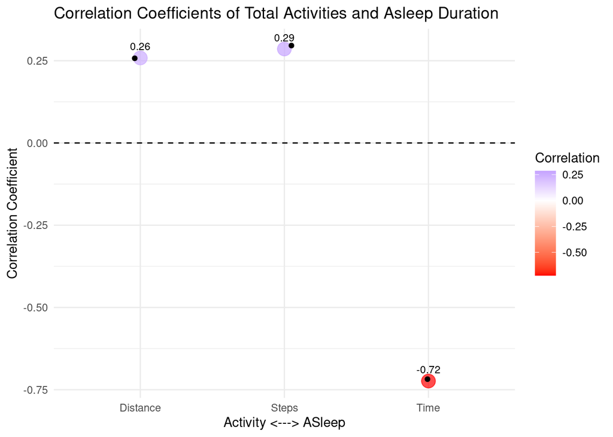

```r
# correlation coefficients
correlation_coefficients <- c(cor_total_step_and_asleep, cor_total_dis_and_asleep, cor_total_activity_time_and_asleep)

# Corresponding labels for each coefficient
labels <- c("Steps", "Distance", "Time")

# Create a data frame
data <- data.frame(
  Variable = labels,
  Correlation = correlation_coefficients
)
# Create a scatterplot
p <- ggplot(data, aes(x = Variable, y = Correlation)) +
  geom_point(aes(color = Correlation), size = 5, alpha = 0.7) +
  geom_jitter(width = 0.05) +
  geom_hline(yintercept = 0, linetype = "dashed", color = "black") +
  scale_color_gradient2(low = "red", mid = "white", high = "blue", midpoint = 0) +
  geom_text(aes(label = round(Correlation, 2)), vjust = -1, size = 3) +
  labs(title = "Correlation Coefficients of Total Activities and Asleep Duration",
       x = "Activity <---> ASleep",
       y = "Correlation Coefficient") +
  theme_minimal()

# Display the plot
print(p)
```

### Correlation Coefficients of Total Activities and Sleep Latency

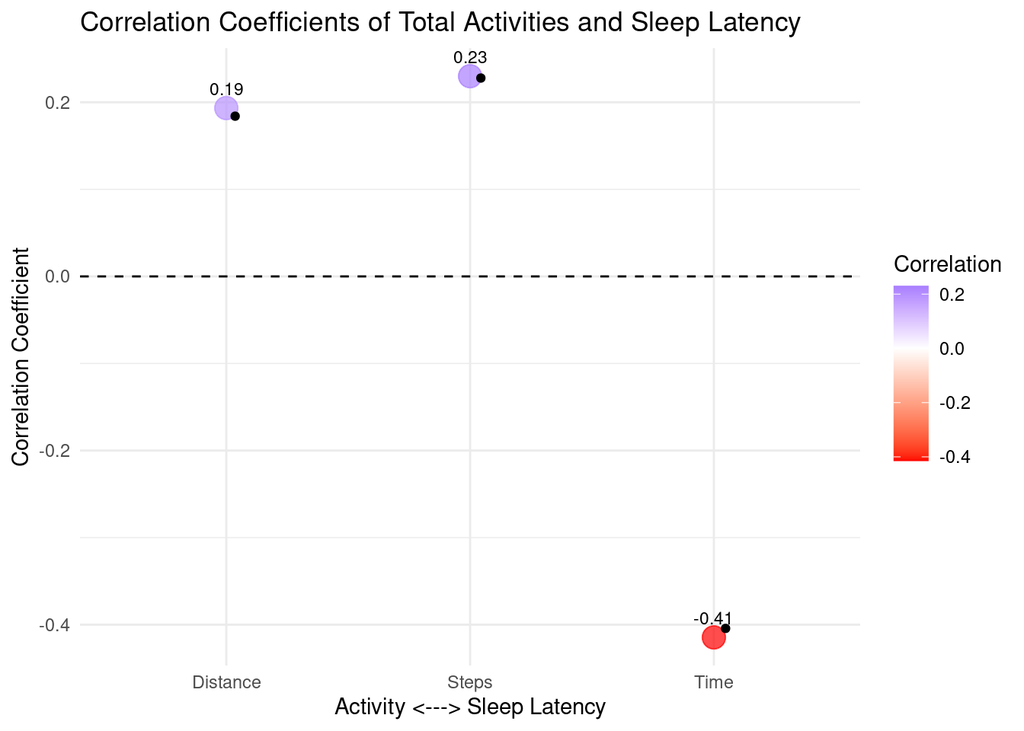

```r
# correlation coefficients
correlation_coefficients <- c(cor_total_step_and_sleep_latency, cor_total_dis_and_sleep_latency, cor_total_activity_time_and_sleep_latency)

# Corresponding labels for each coefficient
labels <- c("Steps", "Distance", "Time")

# Create a data frame
data <- data.frame(
  Variable = labels,
  Correlation = correlation_coefficients
)

# Create a scatterplot
p <- ggplot(data, aes(x = Variable, y = Correlation)) +
  geom_point(aes(color = Correlation), size = 5, alpha = 0.7) +
  geom_jitter(width = 0.05) +
  geom_hline(yintercept = 0, linetype = "dashed", color = "black") +
  scale_color_gradient2(low = "red", mid = "white", high = "blue", midpoint = 0) +
  geom_text(aes(label = round(Correlation, 2)), vjust = -1, size = 3) +
  labs(title = "Correlation Coefficients of Total Activities and Sleep Latency",
       x = "Activity <---> Sleep Latency",
       y = "Correlation Coefficient") +
  theme_minimal()

# Display the plot
print(p)
```

### Very Active Activities in Sleep Latency and Asleep Duration

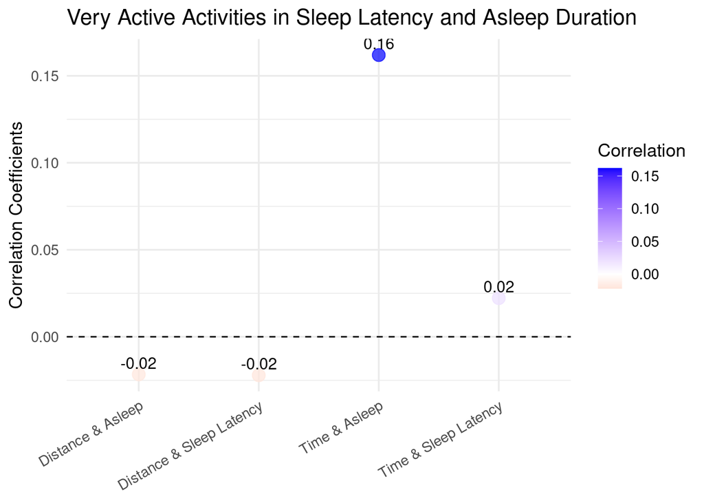

```r
correlation_coefficients <- c(cor_very_active_time_and_asleep, cor_very_active_dis_and_asleep,
            cor_very_active_time_and_sleep_latency, cor_very_active_dis_and_sleep_latency)

# provided correlation labels
labels <- c("Time & Asleep", "Distance & Asleep",
            "Time & Sleep Latency", "Distance & Sleep Latency")

# Create a data frame
data <- data.frame(
  Variable = labels,
  Correlation = correlation_coefficients
)

# Create a scatter plot
p <- ggplot(data, aes(x = Variable, y = Correlation, color = Correlation)) +
  geom_point(size = 4, alpha = 0.7) +
  geom_hline(yintercept = 0, linetype = "dashed", color = "black") +
  scale_color_gradient2(low = "red", high = "blue", mid = "white", midpoint = 0, guide = "colourbar") +
  geom_text(aes(label = sprintf("%.2f", Correlation)), vjust = -0.5, color = "black", size = 4) +
  labs(title = "Very Active Activities in Sleep Latency and Asleep Duration",
       x = NULL,
       y = "Correlation Coefficients") +
  theme_minimal(base_size = 13) +
  theme(axis.text.x = element_text(angle = 30, hjust = 1, vjust = 1),
        legend.position = "right")

# Display the plot
print(p)
```

### Moderately Active Activities in Sleep Latency and Asleep Duration